# Final Info Sheet to Excel

```r
# The code is creating a permmutation distribution for the equality of mean weights for 5 different age groups.  That is, it is testing H_0 : mean(1) = mean(2) = ... mean(5) versus atleast 1 mean(i) not equal to mean(j) for some i not equal to j. based on the pvalue of 0 the evidence suggest that the mean weights are not the same.

## ------------------------------------------------------------------------

# 12: Use the information in ftag to test for an association between Smoker and Gender with the chisq.test() function. State your conclusion after running the test.

T1 <- table(ftag$Smoker, ftag$Gender)
T11 <- ftag %>%
  dplyr::select(Smoker, Gender) %>%
  table()
T1
```

```
##
##       Female Male
##   No     554  629
##   Yes     36   37
```

```r
T11
```

```
##       Gender
## Smoker Female Male
##    No     554  629
##    Yes     36   37
```

```r
chisq.test(T1)
```

```
##
##  Pearson's Chi-squared test with Yates' continuity correction
##
## data:  T1
## X-squared = 0.08529, df = 1, p-value = 0.7703
```

```r
pval <- chisq.test(T1)$p.value
pval
```

```
## [1] 0.7702523
```

```r
B <- 10^4
bt <- numeric(B)
for (i in 1:B) {
  bss <- sample(fullterm$Weight, size = sum(!is.na(fullterm$Weight)), replace = TRUE)
  bt[i] <- ((mean(bss)-mean(fullterm$Weight))/(sd(bss)/sqrt(sum(!is.na(fullterm$Weight)))))
}

Q <- quantile(bt, probs = c(0.05, 0.95))
Q
```

```
##        5%       95%
## -1.662739  1.615056
```

```r
BTCI <- c(mean(fullterm$Weight) - Q[2] * sd(fullterm$Weight)/sqrt(length(fullterm$Weight)),mean(fullterm$Weight) - Q[1] * sd(fullterm$Weight)/sqrt(length(fullterm$Weight)))


smokers <- fullterm %>%
  filter(Smoker == "Yes")

nonsmokers <- fullterm %>%
  filter(Smoker == "No")


B <- 10^4
bt1 <- numeric(B)
for (i in 1:B) {
  bss1 <- sample(nonsmokers$Weight, size = sum(!is.na(nonsmokers$Weight)), replace = TRUE)
  bss2 <- sample(smokers$Weight, size = sum(!is.na(smokers$Weight)), replace = TRUE)
  bt1[i] <- (((mean(bss1) - mean(bss2))-(mean(smokers$Weight)) - mean(nonsmokers$Weight))/sqrt(((sd(bss1)^2)/length(!is.na(smokers$Weight)))+((sd(bss2)^2)/length(!is.na(nonsmokers$Weight)))))
}

perc <- .93 #must be between 1 and 0, 1 = 100%, .9 = 90% ...
l <- (1-(perc))/2
u <- 1-(1-(perc))/2
Q <- quantile(bt1, probs = c(l, u))
Q
```

```
##      3.5%     96.5%
## -74.82248 -61.10059
```

```r
t <- qt(u, 22.821)
t
```

```
## [1] 1.901033
```

```r
t.test(Weight~Smoker, data = fullterm, conf = perc)
```

```
##
##  Welch Two Sample t-test
##
## data:  Weight by Smoker
## t = 1.696, df = 22.821, p-value = 0.1035
## alternative hypothesis: true difference in means is not equal to 0
## 93 percent confidence interval:
##  -24.61774 431.81539
## sample estimates:
##  mean in group No mean in group Yes
##          3436.781          3233.182
```

```r
BTCI <- c(mean(fullterm$Weight) - Q[2] * sd(fullterm$Weight)/sqrt(length(fullterm$Weight)),mean(fullterm$Weight) - Q[1] * sd(fullterm$Weight)/sqrt(length(fullterm$Weight)))
BTCI
```

```
##    96.5%     3.5%
## 4892.544 5222.507
```

```r
ft <- fullterm %>%
  group_by(Smoker) %>%
  summarise(Mean = mean(Weight), SD = sd(Weight), n = n())
ft
```

```
## # A tibble: 2 x 4
##   Smoker  Mean    SD     n
##   <fct>  <dbl> <dbl> <int>
## 1 No     3437.  427.   310
## 2 Yes    3233.  551.    22
```

```r
weightSM <- subset(fullterm, select = Weight, Smoker == "Yes", drop = TRUE)
weightSM
```

```
##  [1] 2807 3317 3430 2807 3544 3657 3175 3799 2920 3033 3289 3175 4394 3062
## [15] 3005 3204 1588 3884 3684 2722 3629 3005
```

```r
weightNSM <- fullterm %>%
  filter(Smoker == "No")
weightNSM <- weightNSM$Weight
weightNSM
```

```
##   [1] 2665 2948 4196 3204 3147 3600 3175 3033 2098 3771 3459 3686 2977 3459
##  [15] 3629 3714 2722 3005 2977 3260 2977 3090 3827 3402 3345 3033 4281 3600
##  [29] 3459 3090 3771 3544 3005 3402 3487 3572 3430 3884 3572 3912 4026 3544
##  [43] 3147 3147 3997 3459 3657 3260 3175 3572 3430 3925 3545 2325 3572 3317
##  [57] 3515 4026 3232 3544 3175 3544 4309 3033 2750 3345 3062 4508 3572 3119
##  [71] 3515 2778 3600 3425 3005 2905 3232 4082 3657 3317 2905 4621 3459 3827
##  [85] 2863 2948 3487 3204 3430 3289 3827 3686 3629 3119 4140 3629 3941 3430
##  [99] 3345 3260 3827 3345 3430 3629 3289 4139 3799 3515 3487 3345 2665 3425
## [113] 3820 3204 3572 3033 4139 4082 3440 3544 3771 3033 3997 3119 3657 3600
## [127] 4440 3033 3430 3090 3260 3147 2977 3771 4082 3204 3815 3345 3317 3119
## [141] 4054 3260 3912 2750 3686 3487 3430 3317 3270 3374 2807 3445 2722 3317
## [155] 3856 3657 3005 3600 3374 3969 2977 2722 2775 4082 3275 3455 3515 3884
## [169] 3402 2835 3856 3090 3459 3204 3827 4111 4366 3884 2977 3580 3380 3714
## [183] 3175 3175 4167 3714 3629 3289 3515 3799 3260 3204 3345 3630 3572 4139
## [197] 3175 3670 3119 2183 2977 3742 3856 3800 2977 3629 3345 3714 3799 3716
## [211] 3686 3345 3487 3742 3289 3175 3714 3175 3317 3232 2778 3572 3544 3260
## [225] 3629 3827 3714 3941 3147 4026 3402 3544 3005 2608 3317 4309 3827 3686
## [239] 4905 3062 2098 3771 3317 3260 3487 3033 3090 3960 3997 3402 3459 3686
## [253] 3374 3345 3232 3260 3544 3232 3600 3884 3062 3155 3969 3544 4876 3232
## [267] 2977 2948 3430 3459 2948 3204 3075 3430 2892 3275 3250 3147 4309 3175
## [281] 3600 3215 2240 3742 3290 3515 2807 2601 3402 2948 3515 3572 3147 3799
## [295] 3017 2863 4167 3969 3572 2970 3005 3657 3544 3402 3374 4215 3374 3460
## [309] 3090 3969
```

```r
B1 <- 10^4
bt2 <- numeric(B1)

for(i in 1:B1) {
  bss3 <- sample(weightNSM,size = length(weightNSM), replace = TRUE)
  bss4 <- sample(weightSM,size = length(weightSM), replace = TRUE)
  bt2[i] <- (((mean(bss3) - mean(bss4))-(mean(weightSM)) - mean(weightNSM))/sqrt(((sd(bss3)^2)/length(!is.na(weightSM)))+((sd(bss4)^2)/length(!is.na(weightNSM)))))
}


wnsm <- fullterm %>%
  filter(Smoker == "No") %>%
  dplyr::select(Weight) %>%
  pull()


wsm <- fullterm %>%
  filter(Smoker == "Yes") %>%
  dplyr::select(Weight) %>%
  pull()

xbarwnsm <- mean(wnsm)
xbarwsm <- mean(wsm)
theta <- xbarwnsm - xbarwsm

B <- 10^4
bt3 <- numeric(B)
for (i in 1:B){
  bss5 <- sample(wnsm, size = length(wnsm), replace = TRUE)
  bss6 <- sample(wsm, size = length(wsm), replace = TRUE)
  bt3[i] <- ((mean(bss5) - mean(bss6)) - theta)/(sqrt(var(bss5)/length(bss5)+var(bss6)/length(bss6)))
}

Q <- quantile(bt3, probs = c(0.025, .975))

CI <- c(theta - Q[2]*(sqrt(var(wnsm)/length(wnsm)+var(wsm)/length(wsm))),theta - Q[1]*(sqrt(var(wnsm)/length(wnsm)+var(wsm)/length(wsm))))
CI
```

```
##     97.5%      2.5%
## -18.94879 472.93059
```

```r
CI <- theta - Q[2:1]*(sqrt(var(wnsm)/length(wnsm)+var(wsm)/length(wsm)))
CI
```

```
##     97.5%      2.5%
## -18.94879 472.93059
```

```r
#permutation test and pvalue with for loop = test hypothesis that mean weight for non smokers - mean weight for smokers = 0 vs alt that they are not equal to 0

xbarwnsm <- mean(wnsm)
xbarwsm <- mean(wsm)
obs_stat <- xbarwnsm - xbarwsm

pt <- numeric(B)

for(i in 1:B) {
  obs <- tapply(fullterm$Weight, sample(fullterm$Smoker), mean)
  pt[i] <- obs[1] - obs[2]
}

pvalue <- (sum(pt >= obs_stat)*2 + 1)/(B+1)
pvalue
```

```
## [1] 0.03489651
```

```r
#prob that (1 <= chisq(15) <= 10)
pchisq(10, 15) - pchisq(1, 15)
```

```
## [1] 0.1802598
```

```r
#prob that (-2 <= tdist(5) <= a) = 0.7 a = ___
(qt(pt(-2, 5)+.7, 5))
```

```
## [1] 0.7301441
```

```r
#prob that (-a <= Z <= a) = 0.95 => a = ____
res <- .95
val <- (1+res)/2
qnorm(val)
```

```
## [1] 1.959964
```

```r
#################################################################

B <- 10^4
bt4 <- numeric(B)
for (i in 1:B){
  bss5 <- sample(wnsm, size = length(wnsm), replace = TRUE)
  bss6 <- sample(wsm, size = length(wsm), replace = TRUE)
  bt4[i] <- ((mean(bss5) / mean(bss6)))
}


perc <- .92 #must be between 1 and 0, 1 = 100%, .9 = 90% ...
l <- (1-(perc))/2
u <- 1-(1-(perc))/2
Q <- quantile(bt4, probs = c(l, u))
Q
```

```
##       4%      96%
## 1.002417 1.137598
```

```r
t.test(Weight~Smoker, data = fullterm, conf = perc)
```

```
##
##  Welch Two Sample t-test
##
## data:  Weight by Smoker
## t = 1.696, df = 22.821, p-value = 0.1035
## alternative hypothesis: true difference in means is not equal to 0
## 92 percent confidence interval:
##  -16.35795 423.55561
## sample estimates:
##  mean in group No mean in group Yes
##          3436.781          3233.182
```

```r
BTCI <- c(mean(fullterm$Weight) - Q[2] * sd(fullterm$Weight)/sqrt(length(fullterm$Weight)),mean(fullterm$Weight) - Q[1] * sd(fullterm$Weight)/sqrt(length(fullterm$Weight)))
BTCI
```

```
##      96%       4%
## 3395.934 3399.185
```

# Basics

## Fundamental Question of Inference

> How does what we actually observe compare to the null hypothesis if we repeat the process many times?

## What is a p-value

> The probability that what we observe is greater than or equal to the observation we made if we assume the null hypothesis is true.

> > A small p-value (typically ≤ 0.05) indicates strong evidence against the null hypothesis, so you reject the null hypothesis.

> > A large p-value (> 0.05) indicates weak evidence against the null hypothesis, so you fail to reject the null hypothesis.

> > > If you reject the null hypothesis then you can only have a type I error.

> > > If you fail to reject the null hypothesis then you can only have a Type II error.

> > > > If they reject or fail or reject and their hypothesis is incorrect they have made an error.

# Bootstrapping

## CLT (Central Limit Theorm)

$x, x_1, x_2, x_3, ... x_n \sim (\mu, \theta)$

# Bootstrapping

> The bootstrap is a procedure that uses the given sample to create a new distribution, called the bootstrap distribution, that approximates the sampling distribution for the sample mean (or for other statistics).

FIRST CHEAT SHEET

### Verizon Problem

```r
head(Verizon)
```

```
##    Time Group
## 1 17.50  ILEC
## 2  2.40  ILEC
## 3  0.00  ILEC
## 4  0.65  ILEC
## 5 22.23  ILEC
## 6  1.20  ILEC
```

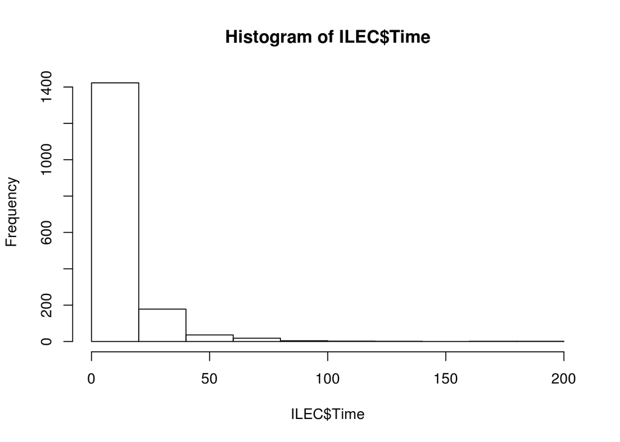

```r
ILEC <- Verizon %>% filter(Group == "ILEC")
CLEC <- Verizon %>% filter(Group == "CLEC")
hist(ILEC$Time)
```

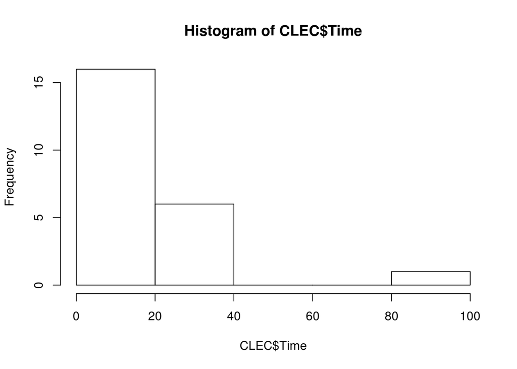

```r
hist(CLEC$Time)
```

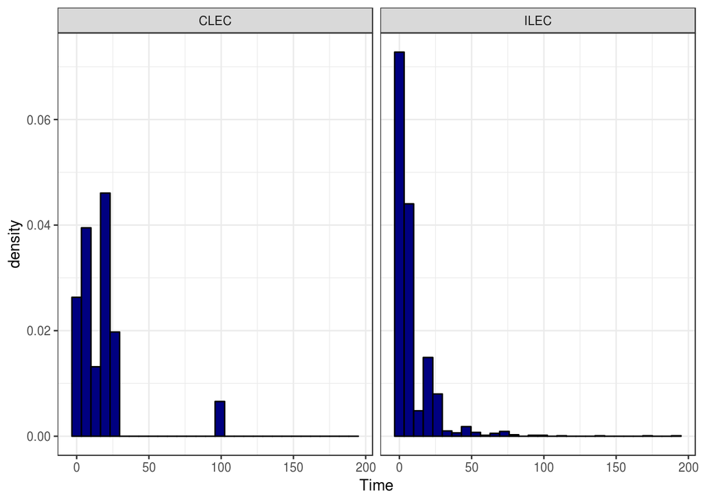

```r
Verizon %>%
ggplot(aes(x = Time,y = ..density..)) +
  geom_histogram(color = "black", fill = "navy") +
  facet_grid(.~Group) +
  theme_bw()
```

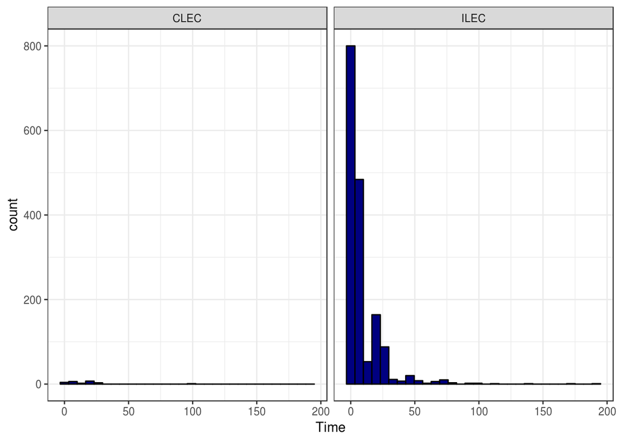

```r
Verizon %>%
ggplot(aes(x = Time)) +
  geom_histogram(color = "black", fill = "navy") +
  facet_grid(.~Group) +
  theme_bw()
```

```r
Verizon %>%
  group_by(Group) %>%
  summarize(m = n(), mean = mean(Time), SD = sd(Time))
```

```
## # A tibble: 2 x 4
##   Group     m  mean    SD
##   <fct> <int> <dbl> <dbl>
## 1 CLEC     23 16.5   19.5
## 2 ILEC   1664  8.41  14.7
```

```r
Times <- Verizon$Time
sims <- 10^2 - 1
ans <- numeric(sims)
for (i in 1:sims) {
  index <- sample(1687, 23, FALSE)
  ans[i] <- mean(Times[index]) - mean(Times[-index])
}

OBS <- tapply(Verizon$Time, Verizon$Group, mean)
OBS
```

```
##      CLEC      ILEC
## 16.509130  8.411611
```

```r
OBS_DIFF <- OBS[1] - OBS[2]
OBS_DIFF
```

```
##    CLEC
## 8.09752
```

```r
pval <- (sum(ans >= OBS_DIFF) + 1)/(sims + 1)
pval
```

```
## [1] 0.04
```

```r
median_ans <- numeric(sims)
for (i in 1:sims) {
  index <- sample(1687, 23, FALSE)
  median_ans[i] <- median(Times[index]) - median(Times[-index])
}

OBS <- tapply(Verizon$Time, Verizon$Group, median)
OBS
```

```
##  CLEC  ILEC
## 14.33  3.59
```

```r
OBS_DIFF <- OBS[1] - OBS[2]
OBS_DIFF
```

```
##  CLEC
## 10.74
```

```r
pval <- (sum(median_ans >= OBS_DIFF) + 1)/(sims + 1)
pval
```

```
## [1] 0.01
```

```r
trimmed_ans <- numeric(sims)
trimamnt <- 0.3
for (i in 1:sims) {
  index <- sample(1687, 23, FALSE)
  trimmed_ans[i] <- mean(Times[index], trim=trimamnt) - mean(Times[-index], trim=trimamnt)
}

OBS <- tapply(Verizon$Time, Verizon$Group, mean, trim = trimamnt)
OBS
```

```
##     CLEC     ILEC
## 13.94000  3.45982
```

```r
OBS_DIFF <- OBS[1] - OBS[2]
OBS_DIFF
```

```
##     CLEC
## 10.48018
```

```r
pval <- (sum(trimmed_ans >= OBS_DIFF) + 1)/(sims + 1)
pval
```

```
## [1] 0.01
```

```r
## Pre test Code

library(infer)
library(resampledata)
library(tidyverse)
#fullterm data is TXBirths where the age is 25-29 gestation is greater than 38 but less or equal to than 42 and no multiples.
fullterm <- TXBirths2004 %>%
  filter(MothersAge == "25-29", Gestation >= 38,
         Gestation <= 42, Multiple == "No")

## ------------------------------------------------------------------------
set.seed(49)
library(infer)
#bootstrapping weight 1000 times from full term and calculating the mean.
bdis <- fullterm %>%
specify(response = Weight) %>%
generate(reps = 1000, type = "bootstrap") %>%
calculate(stat = "mean")
```

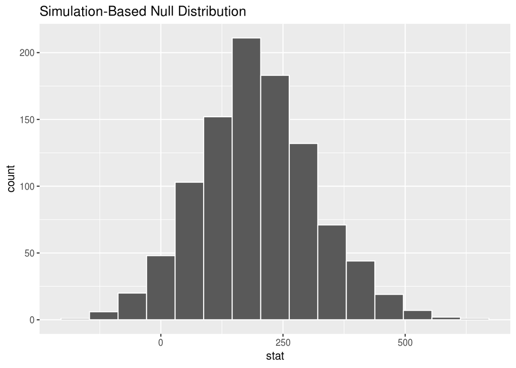

```r
set.seed(39)
#bootstrapping weight vs. smoker 1000 times from full term and calculating diff of the mean for both vars.
dd <- fullterm %>%
  specify(Weight ~ Smoker) %>%
  generate(reps = 1000, type = "bootstrap") %>%
  calculate(stat = "diff in means", order = c("No", "Yes"))
#visualize the bootstrapped data
visualize(dd)
```

```r
#Gets the confidence interval with a level of 90% on the bootstrapped data.
CI <- conf_int(dd, level = 0.90)
CI
```

```
## # A tibble: 1 x 2
##    `5%` `95%`
##   <dbl> <dbl>
## 1  8.88  403.
```

```r
set.seed(19)
null <- fullterm %>%
  specify(Weight ~ Smoker) %>%
  hypothesize(null = "independence") %>%
  generate(reps = 1000, type = "permute") %>%
  calculate(stat = "diff in means", order = c("No", "Yes"))
pval <- p_value(null, obs_stat = 196.924, direction = "right")
pval
```

```
## # A tibble: 1 x 1
##   p_value
##     <dbl>
## 1   0.019
```